# Изучение закономерностей, определяющих успешность игр

## Содержание

- Введение
- Изучение общей информации о данных
- Предобработка данных
  - Приведение имён столбцов к нижнему регистру
  - Обработка пропущенных значений
  - Обработка дубликатов
  - Корректировка типов данных столбцов
  - Подсчёт суммарных продаж во всех регионах
  - Вывод
- Исследовательский анализ данных
  - Определение количества игр, выпускавшихся в разные годы
  - Исследование динамики продаж по платформам
  - Фильтрация данных (по актуальному периоду)
  - Определение платформ-лидеров продаж
  - Построение диаграм размаха для каждой из платформ
  - Влияние отзывов пользователей на продажи внутри одной популярной платформы
  - Влияние отзывов пользователей на продажи (все платформы)
  - Общее распределение игр по жанрам
  - Вывод
- Портрет пользователя каждого региона
  - Самые популярные платформы (топ-5)
  - Самые популярные жанры (топ-5)
  - Влияние рейтинга ESRB на продажи в отдельном регионе
  - Вывод
- Проверка гипотез
  - Средние пользовательские рейтинги платформ Xbox One и PC одинаковые
  - Средние пользовательские рейтинги жанров Action и Sports разные
- Выводы

## Введение

**Краткое описание проекта**: Вы работаете в интернет-магазине «Стримчик», который продаёт по всему миру компьютерные игры. Из открытых источников доступны исторические данные о продажах игр, оценки пользователей и экспертов, жанры и платформы (например, Xbox или PlayStation). Вам нужно выявить определяющие успешность игры закономерности. Это позволит сделать ставку на потенциально популярный продукт и спланировать рекламные кампании.  
Перед вами данные до 2016 года. Представим, что сейчас декабрь 2016 г., и вы планируете кампанию на 2017-й. Нужно отработать принцип работы с данными. Неважно, прогнозируете ли вы продажи на 2017 год по данным 2016-го или же 2027-й — по данным 2026 года.

**Цель проекта**: выявить определяющие успешность игры закономерности.

**Краткий план работы**:  
**Шаг 1**. Открыть файл с данными и изучить общую информацию;  
**Шаг 2**. Подготовить данные (скорректировать названия столбцов, преобразовать данные в нужные типы, обработать пропуски, подсчитать суммарные продажи во всех регионах);  
**Шаг 3**. Провести исследовательский анализ данных;  
**Шаг 4**. Составить портрет пользователя каждого региона;  
**Шаг 5**. Проверить гипотезы;  
**Шаг 6**. Сделать общие выводы.

## Изучение общей информации о данных

Импортируем все библиотеки, необходимые для выполнения проекта.

```python
import pandas as pd
import matplotlib.pyplot as plt
import numpy as np
import scipy.stats as st
import seaborn as sns
from math import factorial, sqrt
from scipy.stats import binom, norm
```

Считываем .CSV-файл с данными в датафрейм `data`. Выведем общую информацию о содержимом.

```python
try:
    data = pd.read_csv('/datasets/games.csv')
except:
    data = pd.read_csv('https://datasets/games.csv')
data.info()
data.head(20)
```

```
<class 'pandas.core.frame.DataFrame'>
RangeIndex: 16715 entries, 0 to 16714
Data columns (total 11 columns):
 #   Column           Non-Null Count  Dtype
---  ------           --------------  -----
 0   Name             16713 non-null  object
 1   Platform         16715 non-null  object
 2   Year_of_Release  16446 non-null  float64
 3   Genre            16713 non-null  object
 4   NA_sales         16715 non-null  float64
 5   EU_sales         16715 non-null  float64
 6   JP_sales         16715 non-null  float64
 7   Other_sales      16715 non-null  float64
 8   Critic_Score     8137 non-null   float64
 9   User_Score       10014 non-null  object
 10  Rating           9949 non-null   object
dtypes: float64(6), object(5)
memory usage: 1.4+ MB
```

|  | Name | Platform | Year_of_Release | Genre | NA_sales | EU_sales | JP_sales | Other_sales | Critic_Score | User_Score | Rating |
| --- | --- | --- | --- | --- | --- | --- | --- | --- | --- | --- | --- |
| 0 | Wii Sports | Wii | 2006.0 | Sports | 41.36 | 28.96 | 3.77 | 8.45 | 76.0 | 8 | E |
| 1 | Super Mario Bros. | NES | 1985.0 | Platform | 29.08 | 3.58 | 6.81 | 0.77 | NaN | NaN | NaN |
| 2 | Mario Kart Wii | Wii | 2008.0 | Racing | 15.68 | 12.76 | 3.79 | 3.29 | 82.0 | 8.3 | E |
| 3 | Wii Sports Resort | Wii | 2009.0 | Sports | 15.61 | 10.93 | 3.28 | 2.95 | 80.0 | 8 | E |
| 4 | Pokemon Red/Pokemon Blue | GB | 1996.0 | Role-Playing | 11.27 | 8.89 | 10.22 | 1.00 | NaN | NaN | NaN |
| 5 | Tetris | GB | 1989.0 | Puzzle | 23.20 | 2.26 | 4.22 | 0.58 | NaN | NaN | NaN |
| 6 | New Super Mario Bros. | DS | 2006.0 | Platform | 11.28 | 9.14 | 6.50 | 2.88 | 89.0 | 8.5 | E |
| 7 | Wii Play | Wii | 2006.0 | Misc | 13.96 | 9.18 | 2.93 | 2.84 | 58.0 | 6.6 | E |
| 8 | New Super Mario Bros. Wii | Wii | 2009.0 | Platform | 14.44 | 6.94 | 4.70 | 2.24 | 87.0 | 8.4 | E |
| 9 | Duck Hunt | NES | 1984.0 | Shooter | 26.93 | 0.63 | 0.28 | 0.47 | NaN | NaN | NaN |
| 10 | Nintendogs | DS | 2005.0 | Simulation | 9.05 | 10.95 | 1.93 | 2.74 | NaN | NaN | NaN |
| 11 | Mario Kart DS | DS | 2005.0 | Racing | 9.71 | 7.47 | 4.13 | 1.90 | 91.0 | 8.6 | E |
| 12 | Pokemon Gold/Pokemon Silver | GB | 1999.0 | Role-Playing | 9.00 | 6.18 | 7.20 | 0.71 | NaN | NaN | NaN |
| 13 | Wii Fit | Wii | 2007.0 | Sports | 8.92 | 8.03 | 3.60 | 2.15 | 80.0 | 7.7 | E |
| 14 | Kinect Adventures! | X360 | 2010.0 | Misc | 15.00 | 4.89 | 0.24 | 1.69 | 61.0 | 6.3 | E |
| 15 | Wii Fit Plus | Wii | 2009.0 | Sports | 9.01 | 8.49 | 2.53 | 1.77 | 80.0 | 7.4 | E |
| 16 | Grand Theft Auto V | PS3 | 2013.0 | Action | 7.02 | 9.09 | 0.98 | 3.96 | 97.0 | 8.2 | M |
| 17 | Grand Theft Auto: San Andreas | PS2 | 2004.0 | Action | 9.43 | 0.40 | 0.41 | 10.57 | 95.0 | 9 | M |
| 18 | Super Mario World | SNES | 1990.0 | Platform | 12.78 | 3.75 | 3.54 | 0.55 | NaN | NaN | NaN |
| 19 | Brain Age: Train Your Brain in Minutes a Day | DS | 2005.0 | Misc | 4.74 | 9.20 | 4.16 | 2.04 | 77.0 | 7.9 | E |

Исследуем, какие значения содержатся в каждом столбце:

```python
data['Platform'].unique()
```

```
array(['Wii', 'NES', 'GB', 'DS', 'X360', 'PS3', 'PS2', 'SNES', 'GBA',
       'PS4', '3DS', 'N64', 'PS', 'XB', 'PC', '2600', 'PSP', 'XOne',
       'WiiU', 'GC', 'GEN', 'DC', 'PSV', 'SAT', 'SCD', 'WS', 'NG', 'TG16',
       '3DO', 'GG', 'PCFX'], dtype=object)
```

В столбце `platform` хранится информация о платформе игры.

Wii — игровая приставка Wii  
NES — игровая приставка Nintendo Entertainment System  
GB — 8-битная портативная игровая система Game Boy  
DS — карманная игровая консоль Nintendo DS  
X360 — игровая приставка Xbox 360  
PS3 — игровая приставка PlayStation 3  
PS2 — игровая приставка PlayStation 2  
SNES — игровая приставка Super Nintendo Entertainment System  
GBA — 32-разрядная портативная игровая система Game Boy Advance  
PS4 — игровая приставка PlayStation 4  
3DS — портативная игровая система Nintendo 3DS  
N64 — 64-разрядная игровая приставка Nintendo 64  
PS — игровая приставка PlayStation  
XB — игровая приставка Xbox  
PC — персональный компьютер  
2600 — игровая приставка Atari 2600  
PSP — портативная игровая система PlayStation Portable  
XOne — игровая приставка Xbox One  
WiiU — игровая консоль WiiU  
GC — игровая консоль Nintendo GameCube  
GEN — игровая приставка Sega Genesis  
DC — игровая приставка Sega Dreamcast  
PSV — портативная консоль PlayStation Vita  
SAT — игровая приставка Sega Saturn  
SCD — Sega Mega-CD (дополнение к игровой приставке Sega Mega Drive)  
WS — портативная игровая консоль WonderSwan  
NG — игровая система Neo-Geo  
TG16 — игровая консоль PC Engine, он же TurboGrafx-16  
3DO — игровая приставка 3DO Interactive Multiplayer  
GG — портативная игровая система Sega Game Gear  
PCFX — игровая приставка PC-FX

```python
data['Year_of_Release'].sort_values().unique()
```

```
array([1980., 1981., 1982., 1983., 1984., 1985., 1986., 1987., 1988.,
       1989., 1990., 1991., 1992., 1993., 1994., 1995., 1996., 1997.,
       1998., 1999., 2000., 2001., 2002., 2003., 2004., 2005., 2006.,
       2007., 2008., 2009., 2010., 2011., 2012., 2013., 2014., 2015.,
       2016.,   nan])
```

В датафрейме представлены данные об играх, которые вышли с 1980 по 2016 г.

```python
data['Genre'].unique()
```

```
array(['Sports', 'Platform', 'Racing', 'Role-Playing', 'Puzzle', 'Misc',
       'Shooter', 'Simulation', 'Action', 'Fighting', 'Adventure',
       'Strategy', nan], dtype=object)
```

В столбце `Genre` хранится информация о жанре игры.

**Sports** — соревнования по существующим видам спорта  
**Platform** — основное внимание уделяется прыжкам или сложностям навигации, часто включают в себя элементы игр-экшенов  
**Racing** — соревнования по времени между персонажами или транспортными средствами  
**Role-Playing** — сосредоточена на прохождении квестов, взаимодействии с неигровыми персонажами, участии в боях, развитии персонажа  
**Puzzle** — сосредоточена на решении абстрактных головоломок  
**Shooter** — игровой процесс основывается на сражениях с использованием огнестрельного или любого другого оружия  
**Simulation** — имитация реальных процессов, часто без указания цели  
**Action** — имеет акцент на борьбе, включает в себя прохождение определённых уровней для достижения битвы с боссами  
**Fighting** — основное внимание уделяется бою один на один  
**Adventure** — делает упор на головоломки без высокой активности  
**Strategy** — с акцентом на тактическое управление ресурсами и территорией против оппонента  
**Misc** — игры, которые нельзя отнести ни к одному из вышеперечисленных жанров

**Вывод**:

- В датафрейме содержатся 11 столбцов и 16 715 строк. В 6 столбцах (`Name`, `Year_of_Release`, `Genre`, `Critic_Score`, `User_Score`, `Rating`) пристуствуют пропущенные значения, которые будут обработаны далее;
- Все названия столбцов нужно привести к нижнему регистру;
- Требуется корректировка типов данных столбцов `Year_of_Release` (`float` → `int`) и `User_Score` (`object` → `float`)

**Комментарий ревьюера**  
👌 Хорошо, изучили данные для предобработки.

## Предобработка данных

### Приведение имён столбцов к нижнему регистру

```python
data.columns = data.columns.str.lower()
data.columns
```

```
Index(['name', 'platform', 'year_of_release', 'genre', 'na_sales', 'eu_sales',
       'jp_sales', 'other_sales', 'critic_score', 'user_score', 'rating'],
      dtype='object')
```

Прежде, чем корректировать тип данных, обработаем пропущенные значения там, где это возможно.

### Обработка пропущенных значений

Определим долю пропущенных значений в каждом столбце.

```python
pd.DataFrame(round(data.isna().mean()*100,1)).style.background_gradient('coolwarm')
```

|  | 0 |
| --- | --- |
| name | 0.000000 |
| platform | 0.000000 |
| year_of_release | 1.600000 |
| genre | 0.000000 |
| na_sales | 0.000000 |
| eu_sales | 0.000000 |
| jp_sales | 0.000000 |
| other_sales | 0.000000 |
| critic_score | 51.300000 |
| user_score | 40.100000 |
| rating | 40.500000 |

#### `name`

```python
data.query('name.isna()')
```

|  | name | platform | year_of_release | genre | na_sales | eu_sales | jp_sales | other_sales | critic_score | user_score | rating |
| --- | --- | --- | --- | --- | --- | --- | --- | --- | --- | --- | --- |
| 659 | NaN | GEN | 1993.0 | NaN | 1.78 | 0.53 | 0.00 | 0.08 | NaN | NaN | NaN |
| 14244 | NaN | GEN | 1993.0 | NaN | 0.00 | 0.00 | 0.03 | 0.00 | NaN | NaN | NaN |

Строки с пропусками в столбце `name` удалим из датафрейма как неинформативные. Возможно, это одна и та же игра: в строке 659 содержится информация о продажах в Севреной Америке, Европе и других регионах, а в строке 14244 — о продажах в Японии.

```python
data = data.dropna(subset=['name'])
#проверим, что не удалилось ничего лишнего
data.info()
```

```
<class 'pandas.core.frame.DataFrame'>
Index: 16713 entries, 0 to 16714
Data columns (total 11 columns):
 #   Column           Non-Null Count  Dtype
---  ------           --------------  -----
 0   name             16713 non-null  object
 1   platform         16713 non-null  object
 2   year_of_release  16444 non-null  float64
 3   genre            16713 non-null  object
 4   na_sales         16713 non-null  float64
 5   eu_sales         16713 non-null  float64
 6   jp_sales         16713 non-null  float64
 7   other_sales      16713 non-null  float64
 8   critic_score     8137 non-null   float64
 9   user_score       10014 non-null  object
 10  rating           9949 non-null   object
dtypes: float64(6), object(5)
memory usage: 1.5+ MB
```

#### `year_of_release`

В столбце `year_of_release` было обнаружено 269 строк с пропусками. Не уверена, что база данных велась вручную с 1985 года, сделаю предположение, что данные выгружены с какого-то стороннего сервиса, где у некоторых игр не были указаны годы выпуска.

```python
data.query('year_of_release.isna()')
```

|  | name | platform | year_of_release | genre | na_sales | eu_sales | jp_sales | other_sales | critic_score | user_score | rating |
| --- | --- | --- | --- | --- | --- | --- | --- | --- | --- | --- | --- |
| 183 | Madden NFL 2004 | PS2 | NaN | Sports | 4.26 | 0.26 | 0.01 | 0.71 | 94.0 | 8.5 | E |
| 377 | FIFA Soccer 2004 | PS2 | NaN | Sports | 0.59 | 2.36 | 0.04 | 0.51 | 84.0 | 6.4 | E |
| 456 | LEGO Batman: The Videogame | Wii | NaN | Action | 1.80 | 0.97 | 0.00 | 0.29 | 74.0 | 7.9 | E10+ |
| 475 | wwe Smackdown vs. Raw 2006 | PS2 | NaN | Fighting | 1.57 | 1.02 | 0.00 | 0.41 | NaN | NaN | NaN |
| 609 | Space Invaders | 2600 | NaN | Shooter | 2.36 | 0.14 | 0.00 | 0.03 | NaN | NaN | NaN |
| ... | ... | ... | ... | ... | ... | ... | ... | ... | ... | ... | ... |
| 16373 | PDC World Championship Darts 2008 | PSP | NaN | Sports | 0.01 | 0.00 | 0.00 | 0.00 | 43.0 | tbd | E10+ |
| 16405 | Freaky Flyers | GC | NaN | Racing | 0.01 | 0.00 | 0.00 | 0.00 | 69.0 | 6.5 | T |
| 16448 | Inversion | PC | NaN | Shooter | 0.01 | 0.00 | 0.00 | 0.00 | 59.0 | 6.7 | M |
| 16458 | Hakuouki: Shinsengumi Kitan | PS3 | NaN | Adventure | 0.01 | 0.00 | 0.00 | 0.00 | NaN | NaN | NaN |
| 16522 | Virtua Quest | GC | NaN | Role-Playing | 0.01 | 0.00 | 0.00 | 0.00 | 55.0 | 5.5 | T |

269 rows × 11 columns

Так как строк с пропусками в столбце `year_of_release` осталось <5% от общего объёма, **удалим их из датафрейма**.

```python
data = data.dropna(subset=['year_of_release'])
data.info()
```

```
<class 'pandas.core.frame.DataFrame'>
Index: 16444 entries, 0 to 16714
Data columns (total 11 columns):
 #   Column           Non-Null Count  Dtype
---  ------           --------------  -----
 0   name             16444 non-null  object
 1   platform         16444 non-null  object
 2   year_of_release  16444 non-null  float64
 3   genre            16444 non-null  object
 4   na_sales         16444 non-null  float64
 5   eu_sales         16444 non-null  float64
 6   jp_sales         16444 non-null  float64
 7   other_sales      16444 non-null  float64
 8   critic_score     7983 non-null   float64
 9   user_score       9839 non-null   object
 10  rating           9768 non-null   object
dtypes: float64(6), object(5)
memory usage: 1.5+ MB
```

#### `genre`

Пропущенные значения в столбце `genre` были устранены вместе с пропусками в столбце `name`.

```python
print("Количество пропущенных значений в столбце genre:", data['genre'].isna().sum())
```

```
Количество пропущенных значений в столбце genre: 0
```

```python
data['genre'].value_counts()
```

```
genre
Action          3307
Sports          2306
Misc            1721
Role-Playing    1481
Shooter         1296
Adventure       1293
Racing          1226
Platform         878
Simulation       857
Fighting         837
Strategy         673
Puzzle           569
Name: count, dtype: int64
```

#### `user_score` и `critic_score`

Пропуски в этих столбцах можно объяснить следующим образом: как правило, для формирования оценки необходимо собрать определённое количество отзывов (как для оценки критиков, так и для пользовательской оценки). Если игра непопулярна (слабая рекламная кампания, узкая целевая аудитория), этот процесс может затянуться на годы. К тому же, в 1985-2000 годы не существовало крупных сайтов с рейтингами видеоигр и чаще всего пользователи делились своими впечатлениями на небольших форумах.

В столбце `user_score` помимо NaN также встречаются значения `tbd` (подлежит уточнению). Можно сделать вывод, что играм со значением `tbd` пользователи поставили слишком мало оценок, поэтому можем их заменить на NaN (чтобы можно было скорректировать тип данных столбца).

```python
data['user_score'].value_counts()
```

```
user_score
tbd    2376
7.8     322
8       285
8.2     276
8.3     252
       ...
1.1       2
1.9       2
9.6       2
0         1
9.7       1
Name: count, Length: 96, dtype: int64
```

```python
data.loc[data['user_score']=='tbd','user_score'] = np.nan
data.info()
```

```
<class 'pandas.core.frame.DataFrame'>
Index: 16444 entries, 0 to 16714
Data columns (total 11 columns):
 #   Column           Non-Null Count  Dtype
---  ------           --------------  -----
 0   name             16444 non-null  object
 1   platform         16444 non-null  object
 2   year_of_release  16444 non-null  float64
 3   genre            16444 non-null  object
 4   na_sales         16444 non-null  float64
 5   eu_sales         16444 non-null  float64
 6   jp_sales         16444 non-null  float64
 7   other_sales      16444 non-null  float64
 8   critic_score     7983 non-null   float64
 9   user_score       7463 non-null   object
 10  rating           9768 non-null   object
dtypes: float64(6), object(5)
memory usage: 1.5+ MB
```

Пропуски в столбцах `critic_score` и `user_score` не будут подвергнуты обработке — любое заполнение исказит результаты корреляционного анализа и статистических тестов.

#### `rating`

1. Организация ESRB была основана в 1994. Игры, выпущенные до этого года, не проходили оценку рейтинга (по данным на 2024 год, многие старые игры всё же прошли сертификацию).
2. Помимо ESRB, существуют другие системы возрастных рейтингов: европейская PEGI, немецкая USK, японская CERO, российская RARS, а также ещё несколько региональных организаций. Если игра не продавалась в Америке, то, ожидаемо, издателю не требовалось оценивать рейтинг игры по системе ESRB.
3. Компании не обязаны предоставлять игру на определение рейтинга до начала официальных продаж, так как её содержимое может значительно измениться в ходе разработки, поэтому часть игр, изданных в 2016 году, могла ещё не получить оценку от агентства.
4. Значительная часть пропущенных значений в столбце `rating` также имеет пропуски в столбцах `user_score` и `critic_score`. Возможно, есть проблемы с синхронизацией данных из источника оценок.

```python
data.query('rating.isna() and na_sales!=0 and user_score.isna() and critic_score.isna()')
```

|  | name | platform | year_of_release | genre | na_sales | eu_sales | jp_sales | other_sales | critic_score | user_score | rating |
| --- | --- | --- | --- | --- | --- | --- | --- | --- | --- | --- | --- |
| 1 | Super Mario Bros. | NES | 1985.0 | Platform | 29.08 | 3.58 | 6.81 | 0.77 | NaN | NaN | NaN |
| 4 | Pokemon Red/Pokemon Blue | GB | 1996.0 | Role-Playing | 11.27 | 8.89 | 10.22 | 1.00 | NaN | NaN | NaN |
| 5 | Tetris | GB | 1989.0 | Puzzle | 23.20 | 2.26 | 4.22 | 0.58 | NaN | NaN | NaN |
| 9 | Duck Hunt | NES | 1984.0 | Shooter | 26.93 | 0.63 | 0.28 | 0.47 | NaN | NaN | NaN |
| 10 | Nintendogs | DS | 2005.0 | Simulation | 9.05 | 10.95 | 1.93 | 2.74 | NaN | NaN | NaN |
| ... | ... | ... | ... | ... | ... | ... | ... | ... | ... | ... | ... |
| 16675 | Original Frisbee Disc Sports: Ultimate & Golf | DS | 2007.0 | Action | 0.01 | 0.00 | 0.00 | 0.00 | NaN | NaN | NaN |
| 16693 | PGA European Tour | N64 | 2000.0 | Sports | 0.01 | 0.00 | 0.00 | 0.00 | NaN | NaN | NaN |
| 16694 | Carmageddon 64 | N64 | 1999.0 | Action | 0.01 | 0.00 | 0.00 | 0.00 | NaN | NaN | NaN |
| 16708 | Woody Woodpecker in Crazy Castle 5 | GBA | 2002.0 | Platform | 0.01 | 0.00 | 0.00 | 0.00 | NaN | NaN | NaN |
| 16713 | Spirits & Spells | GBA | 2003.0 | Platform | 0.01 | 0.00 | 0.00 | 0.00 | NaN | NaN | NaN |

2949 rows × 11 columns

Столбец `rating` содержит категориальные значения. Так же, как и для столбцов с оценками, эти пропуски мы не можем заполнить конкретными значениями рейтинга, но можем заполнить значениями-заглушками `NR` (Not Rated).

```python
data['rating'] = data['rating'].fillna(value="NR")
data.info()
```

```
<class 'pandas.core.frame.DataFrame'>
Index: 16444 entries, 0 to 16714
Data columns (total 11 columns):
 #   Column           Non-Null Count  Dtype
---  ------           --------------  -----
 0   name             16444 non-null  object
 1   platform         16444 non-null  object
 2   year_of_release  16444 non-null  float64
 3   genre            16444 non-null  object
 4   na_sales         16444 non-null  float64
 5   eu_sales         16444 non-null  float64
 6   jp_sales         16444 non-null  float64
 7   other_sales      16444 non-null  float64
 8   critic_score     7983 non-null   float64
 9   user_score       7463 non-null   object
 10  rating           16444 non-null  object
dtypes: float64(6), object(5)
memory usage: 1.5+ MB
```

### Обработка дубликатов

Проверим, есть ли в датафрейме явные дубликаты.

```python
print("Количество явных дубликатов:", data.duplicated().sum())
```

```
Количество явных дубликатов: 0
```

Явные дубликаты отсутствуют. Однако в датафрейме могут приcутствовать дубликаты среди игр с одинаковым названием, платформой и годом выпуска:

```python
data[data.duplicated(subset=['name', 'platform', 'year_of_release'])]
```

|  | name | platform | year_of_release | genre | na_sales | eu_sales | jp_sales | other_sales | critic_score | user_score | rating |
| --- | --- | --- | --- | --- | --- | --- | --- | --- | --- | --- | --- |
| 16230 | Madden NFL 13 | PS3 | 2012.0 | Sports | 0.0 | 0.01 | 0.0 | 0.0 | 83.0 | 5.5 | E |

```python
data.query('name=="Sonic the Hedgehog" and platform=="PS3"')
```

|  | name | platform | year_of_release | genre | na_sales | eu_sales | jp_sales | other_sales | critic_score | user_score | rating |
| --- | --- | --- | --- | --- | --- | --- | --- | --- | --- | --- | --- |
| 1745 | Sonic the Hedgehog | PS3 | 2006.0 | Platform | 0.41 | 0.06 | 0.04 | 0.66 | 43.0 | 4.1 | E10+ |

```python
data.query('name=="Madden NFL 13" and platform=="PS3"')
```

|  | name | platform | year_of_release | genre | na_sales | eu_sales | jp_sales | other_sales | critic_score | user_score | rating |
| --- | --- | --- | --- | --- | --- | --- | --- | --- | --- | --- | --- |
| 604 | Madden NFL 13 | PS3 | 2012.0 | Sports | 2.11 | 0.22 | 0.0 | 0.23 | 83.0 | 5.5 | E |
| 16230 | Madden NFL 13 | PS3 | 2012.0 | Sports | 0.00 | 0.01 | 0.0 | 0.00 | 83.0 | 5.5 | E |

Эти игры имеют различия только в столбцах с информацией о проданных копиях. Объединим данные по каждой игре:

```python
sales_sonic = data[(data['name'] == 'Sonic the Hedgehog') & (data['platform']=='PS3')][['na_sales','eu_sales','jp_sales','other_sales']].sum()
sales_madden = data[(data['name'] == 'Madden NFL 13') & (data['platform']=='PS3')][['na_sales','eu_sales','jp_sales','other_sales']].sum()

data = data.drop_duplicates(subset=['name', 'platform', 'year_of_release'], keep='first')

data.loc[1745, ['na_sales','eu_sales','jp_sales','other_sales']] = sales_sonic
data.loc[604, ['na_sales','eu_sales','jp_sales','other_sales']] = sales_madden

data.query('(name=="Sonic the Hedgehog" and platform=="PS3") or (name=="Madden NFL 13" and platform=="PS3")')
```

|  | name | platform | year_of_release | genre | na_sales | eu_sales | jp_sales | other_sales | critic_score | user_score | rating |
| --- | --- | --- | --- | --- | --- | --- | --- | --- | --- | --- | --- |
| 604 | Madden NFL 13 | PS3 | 2012.0 | Sports | 2.11 | 0.23 | 0.00 | 0.23 | 83.0 | 5.5 | E |
| 1745 | Sonic the Hedgehog | PS3 | 2006.0 | Platform | 0.41 | 0.06 | 0.04 | 0.66 | 43.0 | 4.1 | E10+ |

### Корректировка типов данных столбцов

`year_of_release`: `float` → `int`, так как год может быть только целым числом.  
`user_score`: `object` → `float`, так как оценки пользователей — это количественная переменная, представленная в виде числа с плавающей запятой.

Также следовало бы скорректировать тип данных столбца `critic_score`, так как он принимает только целочисленные значения, но из-за пропусков править тип данных не будем.

```python
data['year_of_release'] = data['year_of_release'].astype(int)
data['user_score'] = data['user_score'].astype(float)
#проверим, что изменения применились
data.dtypes
```

```
name                object
platform            object
year_of_release      int64
genre               object
na_sales           float64
eu_sales           float64
jp_sales           float64
other_sales        float64
critic_score       float64
user_score         float64
rating              object
dtype: object
```

```python
data.info()
```

```
<class 'pandas.core.frame.DataFrame'>
Index: 16443 entries, 0 to 16714
Data columns (total 11 columns):
 #   Column           Non-Null Count  Dtype
---  ------           --------------  -----
 0   name             16443 non-null  object
 1   platform         16443 non-null  object
 2   year_of_release  16443 non-null  int64
 3   genre            16443 non-null  object
 4   na_sales         16443 non-null  float64
 5   eu_sales         16443 non-null  float64
 6   jp_sales         16443 non-null  float64
 7   other_sales      16443 non-null  float64
 8   critic_score     7982 non-null   float64
 9   user_score       7462 non-null   float64
 10  rating           16443 non-null  object
dtypes: float64(6), int64(1), object(4)
memory usage: 2.0+ MB
```

### Подсчёт суммарных продаж во всех регионах

```python
data['all_regions_sales'] =  data.loc[:,['na_sales','eu_sales', 'jp_sales', 'other_sales']].sum(axis=1)

data.head()
```

|  | name | platform | year_of_release | genre | na_sales | eu_sales | jp_sales | other_sales | critic_score | user_score | rating | all_regions_sales |
| --- | --- | --- | --- | --- | --- | --- | --- | --- | --- | --- | --- | --- |
| 0 | Wii Sports | Wii | 2006 | Sports | 41.36 | 28.96 | 3.77 | 8.45 | 76.0 | 8.0 | E | 82.54 |
| 1 | Super Mario Bros. | NES | 1985 | Platform | 29.08 | 3.58 | 6.81 | 0.77 | NaN | NaN | NR | 40.24 |
| 2 | Mario Kart Wii | Wii | 2008 | Racing | 15.68 | 12.76 | 3.79 | 3.29 | 82.0 | 8.3 | E | 35.52 |
| 3 | Wii Sports Resort | Wii | 2009 | Sports | 15.61 | 10.93 | 3.28 | 2.95 | 80.0 | 8.0 | E | 32.77 |
| 4 | Pokemon Red/Pokemon Blue | GB | 1996 | Role-Playing | 11.27 | 8.89 | 10.22 | 1.00 | NaN | NaN | NR | 31.38 |

## Исследовательский анализ данных

### Определение количества игр, выпускавшихся в разные годы

Визуализируем информацию с помощью столбчатой диаграммы.

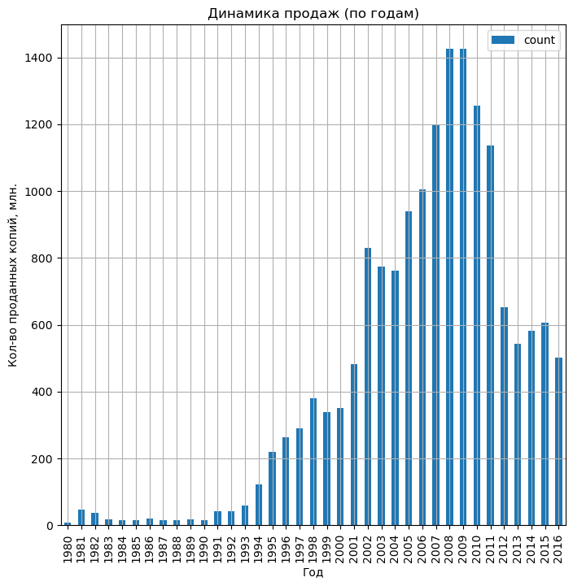

```python
data_games_pivot_table = data.pivot_table(index="year_of_release",values="name", aggfunc="count")
data_games_pivot_table.columns = ['count']
data_games_pivot_table.plot(kind='bar', grid=True, figsize=(8,8))

plt.ylabel("Кол-во проданных копий, млн.")
plt.xlabel("Год");
plt.title("Динамика продаж (по годам)");
```

Из диаграммы видно, что до 1993 года выпускалось достаточно мало игр. Это можно объяснить малым количеством доступных платформ, сложностью разработки, недостаточной развитостью компьютерных технологий, техническими ограничениями, скудностью игровых сюжетов. 1990-е годы были ознаменованы заметными инновациями в компьютерных играх. Основными достижениями называют переход от растровой графики к полностью полигональному 3D, снижение популярности аркадных игр и появление нескольких новых жанров. В 1994 году выпускается игровая приставка PlayStation, которая стала популярной благодаря обширной библиотеке игр, популярным франшизам, низкой розничной цене и агрессивному маркетингу среди молодёжи. После 1994 года продажи игр росли вплоть до 2009 года. После 2009 года заметен сильный спад продаж, связанный с экономическим кризисом 2008 года, а также сменой фокуса пользователей на мобильные платформы и общим затуханием интереса к компьютерным играм.

**Данные за все периоды не важны** — не имеет смысла учитывать информацию о продажах для платформ, которые давно ушли с рынка.

### Исследование динамики продаж по платформам

Для начала определим самые популярные платформы: построим столбчатую диаграмму.

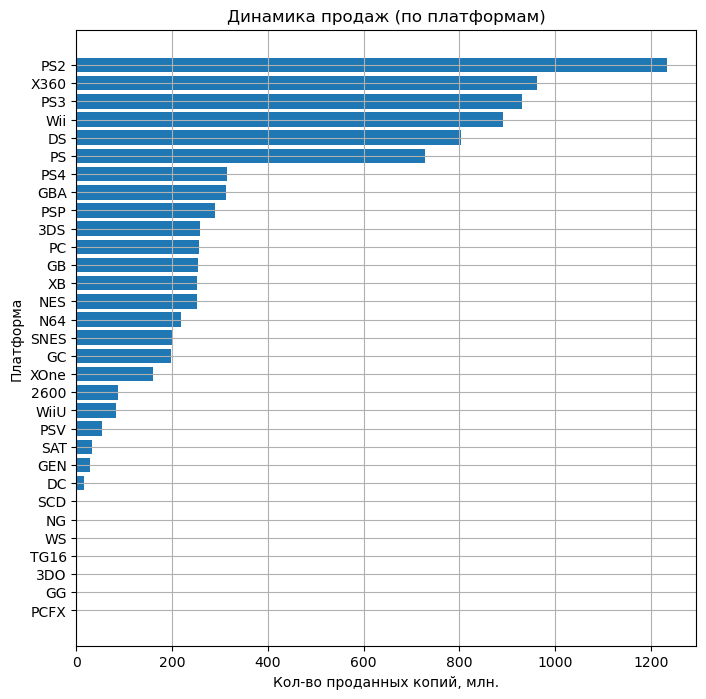

```python
data_platforms_sales = data.pivot_table(index="platform",values="all_regions_sales", aggfunc="sum")
data_platforms_sales.columns = ['sum']
data_platforms_sales = data_platforms_sales.sort_values(by='sum', ascending=True)

plt.figure(figsize=(8, 8))
plt.barh(data_platforms_sales.index.get_level_values(0), data_platforms_sales['sum'])
plt.xlabel("Кол-во проданных копий, млн.")
plt.ylabel("Платформа");
plt.title("Динамика продаж (по платформам)");
plt.grid(True);
```

*При первичном построении графика обнаружила 1 аномальное значение для платформы DS: по данным из таблицы, игра была выпущена в 1985 году, но сама платформа появилась только в 2004.*

```python
data.query('platform=="DS" and year_of_release==1985')
```

|  | name | platform | year_of_release | genre | na_sales | eu_sales | jp_sales | other_sales | critic_score | user_score | rating | all_regions_sales |
| --- | --- | --- | --- | --- | --- | --- | --- | --- | --- | --- | --- | --- |
| 15957 | Strongest Tokyo University Shogi DS | DS | 1985 | Action | 0.0 | 0.0 | 0.02 | 0.0 | NaN | NaN | NR | 0.02 |

По данным из [открытых источников](https://www.suruga-ya.com/en/product/176000588) эта игра была выпущена в 2007 году. Исправим ошибку:

```python
data.loc[15957,'year_of_release'] = 2007
```

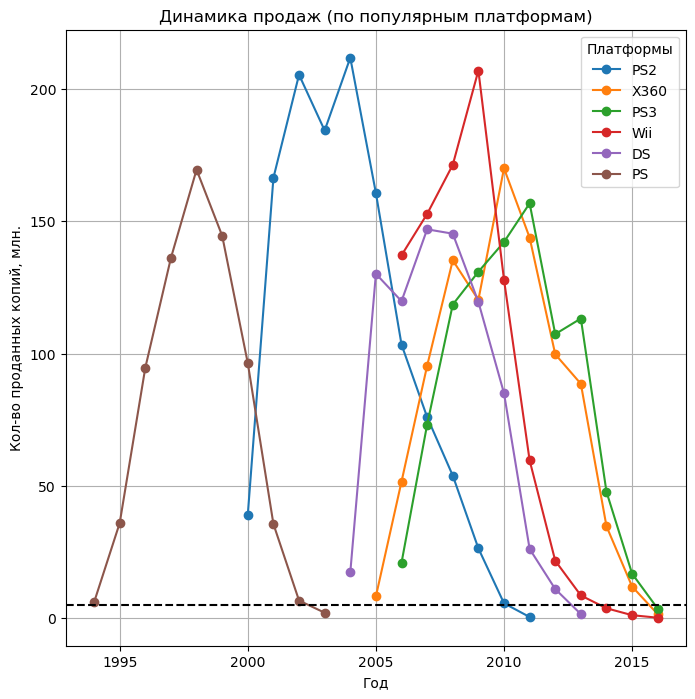

```python
# Построим график для самых популярных платформ
data_platforms_sales = data_platforms_sales.sort_values(by='sum', ascending=False)
popular_platforms = data_platforms_sales.head(6).index.get_level_values(0)


plt.figure(figsize=(8, 8))
for platform_s in popular_platforms:
    data_platform = data.query('platform==@platform_s')
    data_platform_year = data_platform.pivot_table(index="year_of_release", values="all_regions_sales", aggfunc="sum")
    plt.plot(data_platform_year, label = platform_s, marker="o");
    plt.xlabel("Год")
    plt.ylabel("Кол-во проданных копий, млн.");
plt.legend(title='Платформы');
plt.grid(True)
#порог актуальности платформы
plt.axhline(y=5, color='black', linestyle='--')
plt.title('Динамика продаж (по популярным платформам)');
```

```python
temp = data.copy()
time_life = temp.pivot_table(index='platform', values='year_of_release', aggfunc=['min', 'max']).reset_index()
time_life['life'] = time_life['max'] - time_life['min'] + 1 # в срок жизни платформы, должны входить границы диапазона,
                                                            # поэтому +1
print('Медианное значение периода популярности платформы',time_life['life'].median())
```

```
Медианное значение периода популярности платформы 7.0
```

Медианное значение периода популярности платформы составляет 7 лет. Актуальный период для исследования составит половину этого времени, так как половину жизненного цикла продажи растут, а вторую половину — убывают. Возьмём актуальный период равным 4 годам.

### Фильтрация данных (актуальный период)

```python
data_actual = data.query('year_of_release>2012')
data_actual.info()
```

```
<class 'pandas.core.frame.DataFrame'>
Index: 2233 entries, 16 to 16714
Data columns (total 12 columns):
 #   Column             Non-Null Count  Dtype
---  ------             --------------  -----
 0   name               2233 non-null   object
 1   platform           2233 non-null   object
 2   year_of_release    2233 non-null   int64
 3   genre              2233 non-null   object
 4   na_sales           2233 non-null   float64
 5   eu_sales           2233 non-null   float64
 6   jp_sales           2233 non-null   float64
 7   other_sales        2233 non-null   float64
 8   critic_score       991 non-null    float64
 9   user_score         1192 non-null   float64
 10  rating             2233 non-null   object
 11  all_regions_sales  2233 non-null   float64
dtypes: float64(7), int64(1), object(4)
memory usage: 226.8+ KB
```

### Определение платформ-лидеров продаж

Построим графики, чтобы отследить динамику продаж по платформам в актуальном периоде.

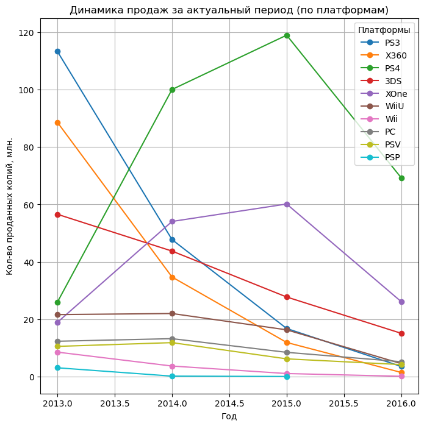

```python
platforms = data_actual['platform'].unique()

plt.figure(figsize=(8, 8))
for platform_s in platforms:
    data_platform = data_actual.query('platform==@platform_s')
    data_platform_year = data_platform.pivot_table(index="year_of_release", values="all_regions_sales", aggfunc="sum")
    if (data_platform_year.shape[0] > 1):
        plt.plot(data_platform_year, label = platform_s, marker="o");

plt.xlabel("Год")
plt.ylabel("Кол-во проданных копий, млн.");
plt.grid(True)
plt.legend(title='Платформы', loc='best');
plt.title("Динамика продаж за актуальный период (по платформам)");
```

В 2014 году в лидеры продаж вырвались игры на платформе PS4 (100 млн. копий) и XOne (~55 млн. копий) (являются прямыми конкурентами, обе игровые приставки были представлены в 2013 году). Игры для PS3 опустилиcь на третье место, а игры для X360 — на пятое (прямые конкуренты предыдущей серии).

В 2015 году лидерство сохранили игры для PS4 и XOne, при этом для PlayStation 4 было продано в 2 раза больше копий, чем для Xbox One.

Согласно графику на основе актуальных данных, к концу 2016 года **продажи всех платформ падают**.

**Потенциально прибыльными платформами** можно считать PlayStation 4, Xbox One, Nintendo 3DS (на момент 2016 года эти платформы можно считать «новичками» на рынке), а так же персональные компьютеры и WiiU.

### Построение диаграмм размаха для каждой из платформ

Проанализируем, как отличаются медианные продажи по каждой из платформ.

| platform | Q1 | median | Q3 | count | max | mean | min | average | high_norm_border |
| --- | --- | --- | --- | --- | --- | --- | --- | --- | --- |
| X360 | 0.0800 | 0.265 | 0.7950 | 186.0 | 16.27 | 0.735484 | 0.01 | 1.663275 | 1.8675 |
| XOne | 0.0600 | 0.220 | 0.6850 | 247.0 | 7.39 | 0.645020 | 0.01 | 1.036139 | 1.6225 |
| PS4 | 0.0600 | 0.200 | 0.7300 | 392.0 | 14.63 | 0.801378 | 0.01 | 1.609456 | 1.7350 |
| WiiU | 0.0600 | 0.200 | 0.5950 | 115.0 | 7.09 | 0.562000 | 0.01 | 1.038778 | 1.3975 |
| Wii | 0.0450 | 0.180 | 0.7550 | 23.0 | 3.58 | 0.593913 | 0.01 | 0.915432 | 1.8200 |
| DS | 0.0675 | 0.150 | 0.2525 | 8.0 | 0.51 | 0.192500 | 0.03 | 0.172026 | 0.5300 |
| PS3 | 0.0400 | 0.150 | 0.5100 | 345.0 | 21.05 | 0.525884 | 0.01 | 1.451939 | 1.2150 |
| 3DS | 0.0400 | 0.090 | 0.2800 | 303.0 | 14.60 | 0.472772 | 0.01 | 1.381347 | 0.6400 |
| PC | 0.0300 | 0.080 | 0.2300 | 189.0 | 3.05 | 0.208624 | 0.01 | 0.352304 | 0.5300 |
| PSV | 0.0200 | 0.040 | 0.1100 | 358.0 | 1.96 | 0.092151 | 0.01 | 0.153816 | 0.2450 |
| PSP | 0.0150 | 0.020 | 0.0700 | 67.0 | 0.24 | 0.052239 | 0.01 | 0.059768 | 0.1525 |

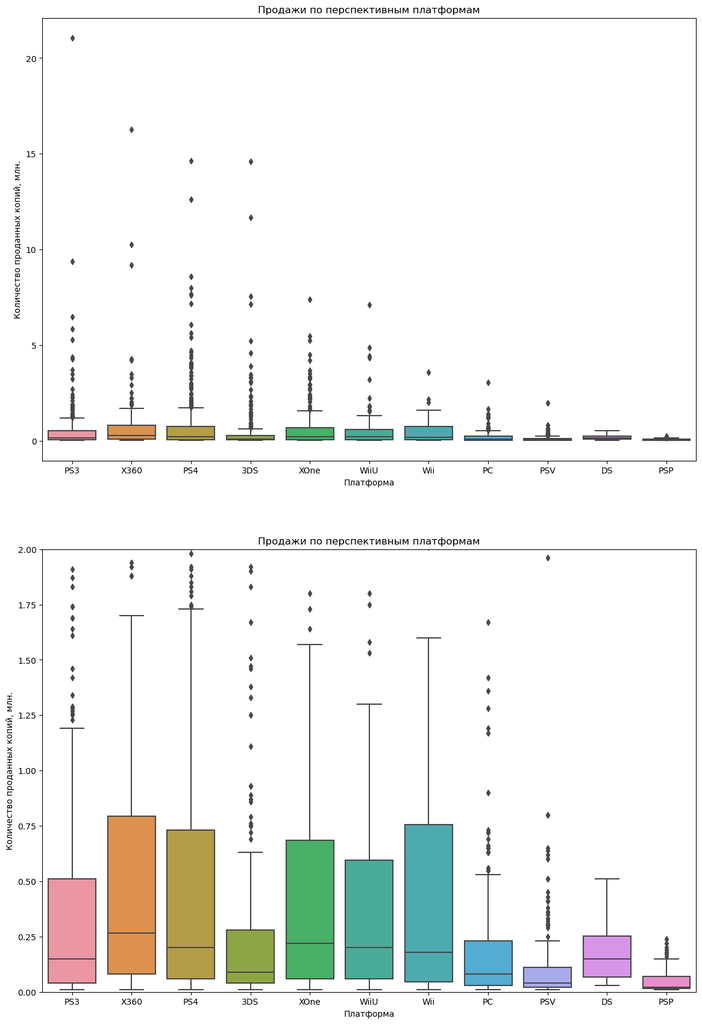

```python
plt.figure(figsize=(14,21))
plt.subplot(2, 1, 1)
sns.boxplot(x="platform", y="all_regions_sales", data=data_actual)
plt.xlabel('Платформа')
plt.ylabel('Количество проданных копий, млн.')
plt.title('Продажи по перспективным платформам')
plt.subplot(2, 1, 2)
sns.boxplot(x="platform", y="all_regions_sales", data=data_actual)
plt.ylim(0,2)
plt.xlabel('Платформа')
plt.ylabel('Количество проданных копий, млн.')
plt.title('Продажи по перспективным платформам');

platform_median_sales = data_actual.pivot_table(index='platform', values='all_regions_sales', aggfunc=['describe'])
platform_median_sales.columns=['Q1','median','Q3','count','max','mean','min','average']
platform_median_sales['high_norm_border'] = platform_median_sales['Q3'] + 1.5*(platform_median_sales['Q3'] - platform_median_sales['Q1'])
platform_median_sales.sort_values(by="median",ascending=False)
```

Представленные выше диаграммы лучше всего рассмотреть группами:

- **портативные игровые консоли** Nintendo DS (DS), Nintendo 3DS (3DS), PlayStation Vita (PSV) и PlayStation Portable (PSP). Наибольшее значение медианы можем наблюдать у платформы DS (150 000 копий), однако все продажи игр для этой платформы лежат в границах от 0 до 530 000 копий, что гораздо меньше границ 3DS (от 0 до 640 000 копий). Также можно заметить, что на диаграмме для платформы 3DS присутствует значительное количество выбросов — популярных игр для этой платформы. Медианное значение продаж PlayStation Vita составляет примерно 40 000 копий. В этой четвёрке PSP можно считать аутсайдером — медианное значение продаж составляет 20 000 копий, продажи лежат в границах от 0 до 152 500 копий. Этого можно было ожидать — в выбранный актуальный период PSP уже «на закате», на смену приходит PSV.
- **Игровые приставки семейства Xbox**: Xbox 360 и Xbox One. Из диаграммы видно, что медианное значение продаж для Xbox 360 больше, нежели для Xbox One: 265 000 копий против 220 000. В 2013 году новое поколение Xbox только появилось на рынке, а модель 360 ещё была достаточно популярна. Насколько я знаю, некоторые игры Xbox 360 обратно совместимы с Xbox One (то есть на новой платформе можно иглать в игры для приставки предыдущего поколения, чем пока не могла похвастаться PS4). Пользователи, апгрейднувшие свою консоль могли пока играть в старые игры и не окупать новых для Xbox One. Исходя из графика продаж по годам, Xbox One пока не удалось достигнуть того же успеха, что и её предшественнице.
- **Игровые приставки семейства PlayStation**: PlayStation 3 и PlayStation 4. В отличие от Xbox, для платформы PS4 удалось продать больше игр, нежели для PS3 (можно наблюдать положительную динамику: с выходом новой модели PS продаётся больше копий под новую платформу). Медианное значение продаж для PS4 составляет 200 000 копий, границы распределения лежат от 0 до 1 735 000 копий + значительное количество выбросов за границами нормального распределения. Для PS3 медианным значением является 150 000 проданных копий, также можно заметить, что границы распределения продаж более узкие, нежели для PS4 (от 0 до 1 215 000 копий).
- **Игровые приставки семейства Wii**: Wii и WiiU. Несмотря на то, что в выбранный актуальный период Wii уже была не нова, она показывает неплохие значения медианы и границ распределения. Медианное значение продаж Wii составляет 180 000 копий, границы распределения продаж от 0 до 1 820 000 копий. В своё время она была достаточно популярной. WiiU, несмотря на большее значение медианы (200 000 копий), имеет более узкие границы распределения (от 0 до 1 397 500 копий). Возможно, потенциал WiiU раскрылся не до конца, но, исходя из графика продаж для всех платформ за актуальное время, она не так популярна, как приставки семейства Xbox и PS.
- **Персональные компьютеры (PC)**. Эта платформа является самой распространённой в мире, а также единственной платформой без «срока жизни». Медианное значение продаж составляет 80 000 копий, границы нормального распределения продаж — 0 и 530 000 копий. Малое количество продаж можно объяснить следующим образом: персональные компьютеры обычных пользователей не успевают за техническими требованиями к играм. Для комфортной игры требуется мощная видеокарта, современный процессор с высокой тактовой частотой и большим количеством ядер, достойный объём оперативной памяти. Все эти комплектующие достаточно дорогие. Также игры для PC часто взламываются, пользователь может легко получить игру бесплатно.

*Среди портативных консолей наиболее перспективной является Nintendo 3DS. Среди приставок больше всего продаж приходится на игры для PS4, но медианное значение продаж больше у Xbox One (200 000 копий у PS4 и 220 000 копий у XBox One). WiiU так же не отстаёт по медианным продажам от PS4 (200 000 копий) хоть и суммарно игр для этой платформы продается меньше (для этой платформы ыло выпущено мало игр бестселлеров)*

### Влияние отзывов пользователей на продажи внутри одной популярной платформы

Построим диаграммы рассеяния и рассчитаем корреляцию между оценками (пользователей и критиков) и количеством проданных копий для оценки влияния на продажи. Первые рассчёты произведём для платформы PS4.

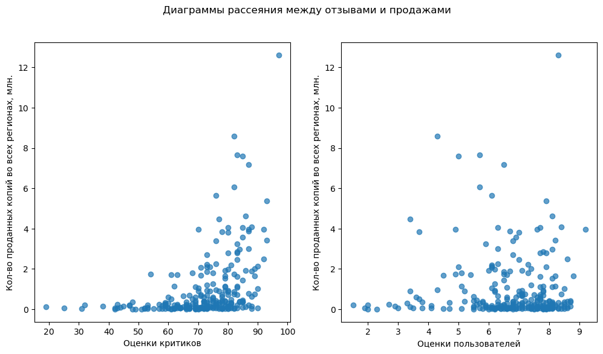

```python
data_PS4 = data_actual.query('platform=="PS4"')

fig, (ax1, ax2) = plt.subplots(1, 2, figsize=(12, 6))
ax1.scatter(x = data_PS4['critic_score'], y = data_PS4['all_regions_sales'], alpha = 0.7)
ax1.set_xlabel('Оценки критиков')
ax1.set_ylabel('Кол-во проданных копий во всех регионах, млн.')
ax2.scatter(x = data_PS4['user_score'], y = data_PS4['all_regions_sales'], alpha = 0.7)
ax2.set_xlabel('Оценки пользователей')
ax2.set_ylabel('Кол-во проданных копий во всех регионах, млн.')
fig.suptitle('Диаграммы рассеяния между отзывами и продажами');
```

```python
data_PS4_sales_and_scores = data_PS4.loc[:,['user_score','critic_score','all_regions_sales']]
data_PS4_sales_and_scores.corr()
```

|  | user_score | critic_score | all_regions_sales |
| --- | --- | --- | --- |
| user_score | 1.000000 | 0.557654 | -0.031957 |
| critic_score | 0.557654 | 1.000000 | 0.406568 |
| all_regions_sales | -0.031957 | 0.406568 | 1.000000 |

Существует корреляция между оценками критиков и продажами игры. Связь между пользовательскими оценками и продажами отсутствует.

### Влияние отзывов пользователей на продажи (все перспективные платформы)

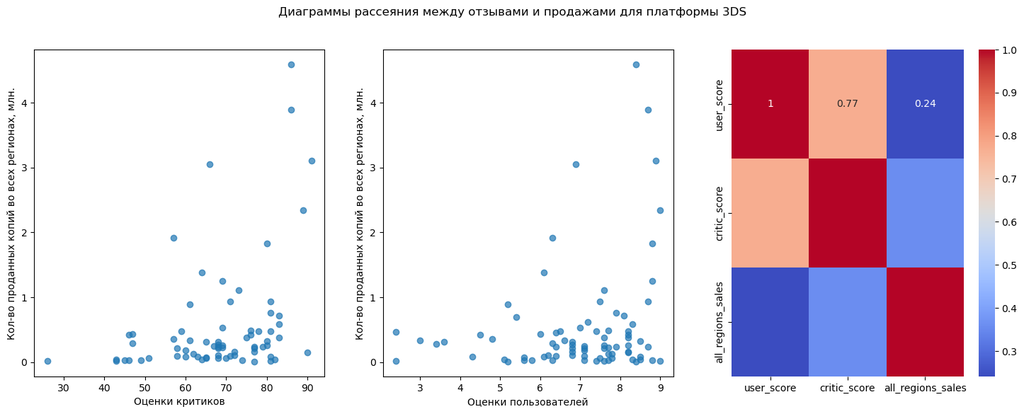

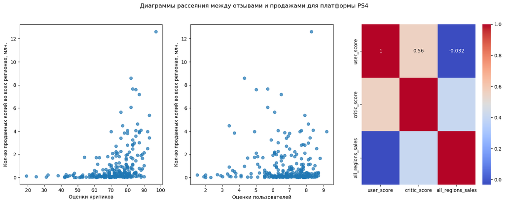

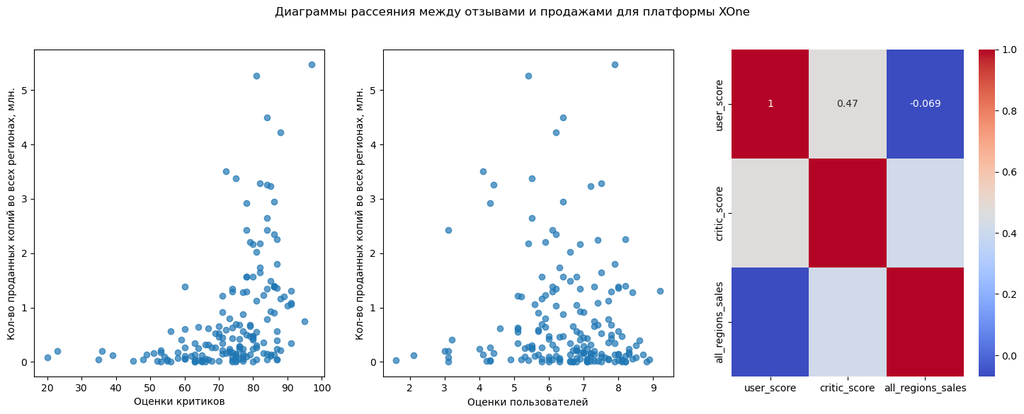

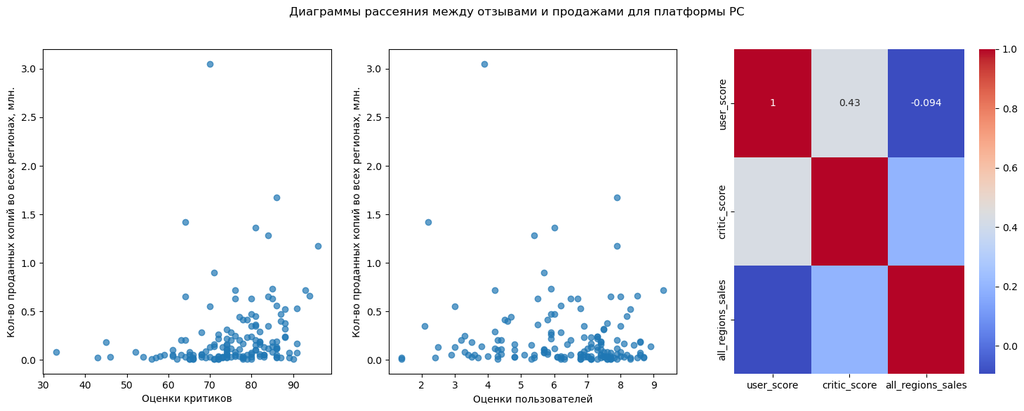

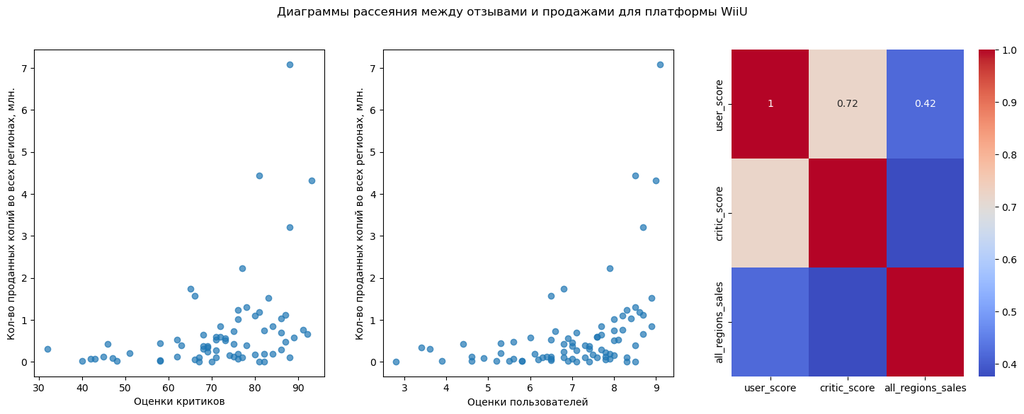

```python
platforms = ['3DS', 'PS4', 'XOne', 'PC', 'WiiU']

for platform in platforms:
    data_platform = data_actual.query('platform==@platform')
    fig, (ax1, ax2, ax3) = plt.subplots(1, 3, figsize=(18, 6))
    ax1.scatter(x = data_platform['critic_score'], y = data_platform['all_regions_sales'], alpha = 0.7)
    ax1.set_xlabel('Оценки критиков')
    ax1.set_ylabel('Кол-во проданных копий во всех регионах, млн.')
    ax2.scatter(x = data_platform['user_score'], y = data_platform['all_regions_sales'], alpha = 0.7)
    ax2.set_xlabel('Оценки пользователей')
    ax2.set_ylabel('Кол-во проданных копий во всех регионах, млн.')
    data_corr_matrix = data_platform.loc[:,['user_score','critic_score','all_regions_sales']].corr()
    ax3 = sns.heatmap(data_corr_matrix, cmap='coolwarm',annot=True)
    fig.suptitle('Диаграммы рассеяния между отзывами и продажами для платформы {}'.format(platform));
```

**Вывод:** исходя из диаграмм рассеяния и значений корреляций, оценки пользователей не влияют на продажи (верно для всех платфом, кроме WiiU и 3DS), в то время как оценки критиков оказывают слабое или очень слабое влияние на продажи.

### Общее распределение игр по жанрам

Построим столбчатую диаграмму для визуализации распределения игр по жанрам:

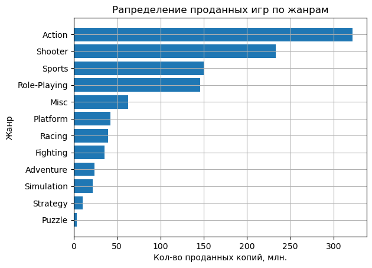

```python
data_genre_sales = data_actual.pivot_table(index='genre', values='all_regions_sales', aggfunc=['sum'])
data_genre_sales.columns = ['sum']
data_genre_sales = data_genre_sales.sort_values(by='sum', ascending=True)
plt.barh(data_genre_sales.index.get_level_values(0), data_genre_sales['sum'])
plt.xlabel("Кол-во проданных копий, млн.")
plt.ylabel("Жанр");
plt.title("Рапределение проданных игр по жанрам");
plt.grid(True);
```

Сравним медианные продажи в каждом жанре:

```python
data_genre_sales_pivot = data_actual.pivot_table(index='genre', values = 'all_regions_sales', aggfunc='median')
data_genre_sales_pivot.columns=['median_sales']
data_genre_sales_pivot.sort_values(by="median_sales", ascending = False)
```

| genre | median_sales |
| --- | --- |
| Shooter | 0.450 |
| Sports | 0.240 |
| Platform | 0.225 |
| Role-Playing | 0.125 |
| Fighting | 0.125 |
| Racing | 0.120 |
| Action | 0.110 |
| Simulation | 0.100 |
| Misc | 0.100 |
| Strategy | 0.080 |
| Puzzle | 0.060 |
| Adventure | 0.030 |

Не смотря на то, что игр в жанре Action продается больше всего, их медианное значение продаж одной копии составляет всего 100 000! Дополнительно проиллюстрируем полученные результаты диаграммой размаха по жанрам:

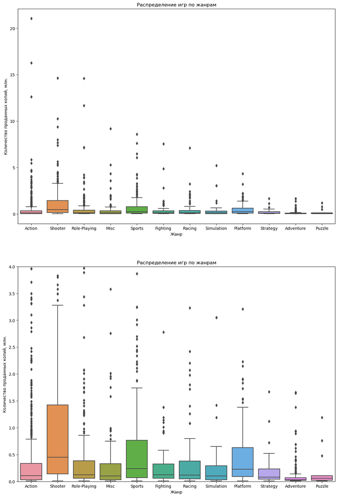

```python
plt.figure(figsize=(14,21))
plt.subplot(2, 1, 1)
sns.boxplot(x="genre", y="all_regions_sales", data=data_actual)
plt.xlabel('Жанр')
plt.ylabel('Количество проданных копий, млн.')
plt.title('Распределение игр по жанрам')
plt.subplot(2, 1, 2)
sns.boxplot(x="genre", y="all_regions_sales", data=data_actual)
plt.ylim(0,4)
plt.xlabel('Жанр')
plt.ylabel('Количество проданных копий, млн.')
plt.title('Распределение игр по жанрам');
```

Наиболее стабильным с точки зрения продаж оказался жанр Shooter. Медианное значение продаж одной игры составляет 450 000 копий. Так же можно заметить что границы нормального распределения продаж этого жанра значительно превышают все оставльные. Жанр Action "выигрывает" по количеству проданных копий за счёт большого количества «выбросов» — игр-хитов, в этом жанре их самое большое количество. На втором месте по величине медианного значения продаж расположился жанр Sports (250 000 копий одной игры), на третьем месте платформеры с медианным значением равным 225 000 копий.

Самыми непопулярными жанрами являются Strategy, Adventure и Puzzle. Медианные значения продаж игр этих жанров менее 100 000 копий. Медиана продаж Adventure самая маленькая среди всех жанров — 30 000 копий, но за счёт большого количества выбросов жанру удалось подняться в общем рейтинге продаж на 9 место.

### Вывод

В ходе исследовательского анализа выявили следующее:

1. При планировании рекламных кампаний не следует учитывать данные о продажах для платформ, которые давно ушли с рынка.
2. Средний "срок жизни" платформы соствляет 7 лет. Так как половину жизненного цикла продажи растут, а вторую половину — убывают, актуальным периодом для построения прогноза на 2017 год будем считать последние 4 года: 2013-2016.
3. Наиболее перспективными платформами являются PlayStation 4, Xbox One, Nintendo 3DS, WiiU и PC.
4. Отзывы пользователей не влияют на количество проданных копий (верно для всех платформ, кроме Nintendo 3DS и WiiU), оценки критиков слабо коррелириуют с продажами.
5. Наиболее популярными жанрами являются Shooter, Sports и Platform.

## Портрет пользователя каждого региона

Определим для каждого региона:

### Самые популярные платформы (топ-5)

Визуализируем рейтинги с помощью круговой диаграммы:

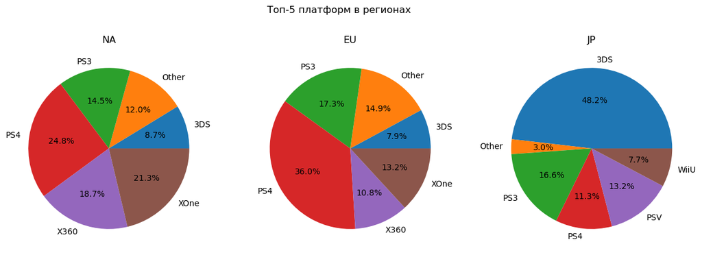

```python
plt.figure(figsize=(15,5))
regions = ['na', 'eu', 'jp']
i=1
for region in regions:
    column_name = '{}_sales'.format(region)
    current = data_actual.groupby('platform').agg({column_name:'sum'}).reset_index()
    current['share']=current[column_name]/current[column_name].sum()
    current = current.sort_values(by='share', ascending=False).reset_index()
    top_five = current.loc[4, 'share']
    current.loc[current['share'] < top_five, 'platform'] = 'Other'
    current = current.groupby('platform').agg({column_name:'sum'}).reset_index()
    current.plot(y=column_name,
                 kind='pie',
                 autopct='%1.1f%%',
                 legend = None,
                 labels=current['platform'].unique(),
                 ylabel="",
                 ax = plt.subplot(1, 3, i))
    plt.title('{}'.format(region.upper()))
    i+=1
plt.suptitle("Топ-5 платформ в регионах");
```

**В Северной Америке** наиболее популярной платформой является PlayStation 4 (игры для этой платформы занимают почти 25% рынка), Xbox One (21.3%), Xbox 360 (18.7%), PlayStation 3 (14.5%) и Nintendo 3DS (8.7%). Хорошо видно, как PS4 и Xbox One, а так же PS3 и Xbox 360 конкурируют между собой.

**В Европе** лидирующей платформой является PlayStation 4 (занимает 36% от всех продаж за актуальный период) На втором месте располагается PS3, на третьем и четвёртом — консоли семейства Xbox (One и 360 сооответтсвенно). В Европе игроки отдают предпочтение консолям семейства PlayStation.

И в Северной Америке, и в Европе, Nintendo 3DS располагается на пятом месте по популярности, что говорит о большей популярности стационарных игровых приставок, нежели портативных консолей.

**В Японии**, напротив, самой популярной платформой является портативная Nintendo 3DS (почти 50%). На втором месте по популярности располагается PlayStation 3, на третьем — ещё одна портативная консоль PlayStation Vita. Замыкают рейтинг PlayStation 4 и WiiU.Также можно заметить, что в топ-5 не попали консоли семейства Xbox, что можно объяснить влияением внутреннего рынка Японии.

### Самые популярные жанры (топ-5)

По аналогии с определением топ-5 платформ для различных регионов используем столбчатые круговые диаграммы:

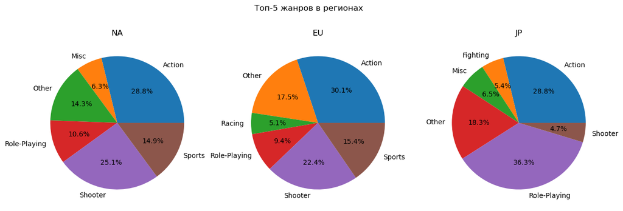

```python
plt.figure(figsize=(15,5))

regions = ['na', 'eu', 'jp']
i=1
for region in regions:
    column_name = '{}_sales'.format(region)
    current = data_actual.groupby('genre').agg({column_name:'sum'}).reset_index()
    current['share']=current[column_name]/current[column_name].sum()
    current = current.sort_values(by='share', ascending=False).reset_index()
    top_five = current.loc[4, 'share']
    current.loc[current['share'] < top_five, 'genre'] = 'Other'
    current = current.groupby('genre').agg({column_name:'sum'}).reset_index()
    current.plot(y=column_name, kind='pie', autopct='%1.1f%%', legend = None, labels=current['genre'].unique(), ylabel="", ax = plt.subplot(1, 3, i))
    plt.title('{}'.format(region.upper()))
    i+=1
plt.suptitle("Топ-5 жанров в регионах");
```

В **Северной Америке** и **Европе** игрокам больше всего нравятся экшн-игры и шутеры (эти два жанра охватывают половину продаж в этих регионах). Спортивные игры и ролевые занимают почти одинаковые доли рынков в этих регионах (14.9% и 10.6% соответственно в Америке и 15.4% и 9.4% — в Европе). В Северной Америке на пятом месте по популярности расположился жанр Misc (6.3%), а в Европе — Racing (5.1%).

### Влияние рейтинга ESRB на продажи в отдельном регионе

При составлении рейтинга не будем отсеивать игры без оценки ESRB.

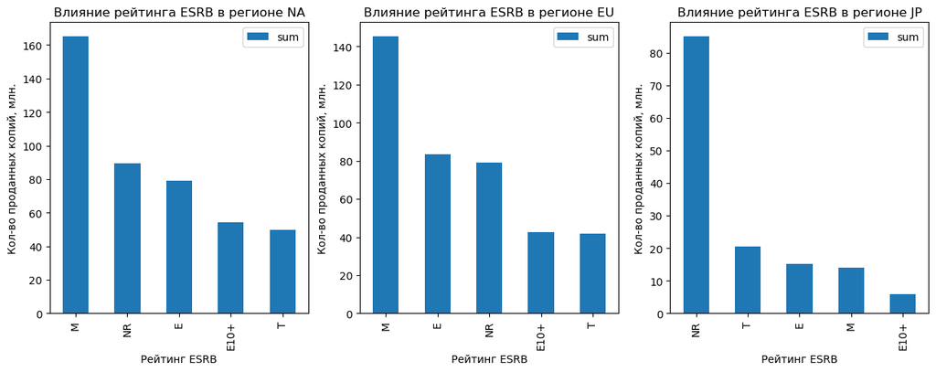

```python
plt.figure(figsize=(15,5))

regions = ['na', 'eu', 'jp']
i=1
for region in regions:
    column_name = '{}_sales'.format(region)
    data_top_raiting = data_actual.pivot_table(index='rating', values=column_name, aggfunc=['sum'])
    data_top_raiting.columns = ['sum']
    data_top_raiting = data_top_raiting.sort_values(by='sum', ascending=False)
    data_top_raiting.plot(y = 'sum', kind='bar', ax = plt.subplot(1,3,i))
    plt.title('Влияние рейтинга ESRB в регионе {}'.format(region.upper()))
    plt.ylabel('Кол-во проданных копий, млн.')
    plt.xlabel('Рейтинг ESRB')
    i+=1
```

Если не принимать во внимание игры без рейтинга **для регионов NA и EU**, можно сказать, что распределения очень схожи: самыми популярными играми являются игры с рейтингом «М» («Для взрослых»), на втором месте — «E» («Для всех»), на третьем — «E10+» («Для пользователей старше 10 лет»), на четвёртом — «T» («Teen») — «Подросткам».

**В Японии** большая часть игр не имеет рейтинга ESRB (как указано выше, у Японии есть своя система рейтинга игр). Если рассматривать игры, прошедшие оценку: самыми популярными являются игры для подростков («T»). На втором месте — игры с рейтингом («E»), на третьем, с небольшим отставанием — игры «Для взрослых». Замыкают рейтинг игры с пометкой («Для пользователей старше 10 лет»).

### Вывод:

1. В Европе и в Северной Америке игроки отдают предпочтение стационарным игровым приставкам, в то время как в Японии наиболее популярны портативные консоли.
2. Касательно жанров — в Северной Америке и Европе у пользователей схожие предпочтения (экшн-игры, шутеры, спортивные и ролевые игры). В Японии игроки больше всего любят ролевые игры, но также неравнодушны к экшенам.
3. Можем наблюдать схожесть поведения пользователей Северной Америки и Европы в проекции влияния рейтинга ESRB на продажи. Наиболее популярными являются игры «Для взрослых», на втором месте — «E» («Для всех»), на третьем — «E10+» («Для пользователей старше 10 лет»), на четвёртом — «T» («Teen») — «Подросткам». В Японии эта система рейтингов не распространена, поэтому сложно дать оценку, игры какого рейтинга популярны в этом регионе. Среди игр, прошедших оценку, у игроков популярны игры для подростков («T»). На втором месте — игры с рейтингом («E»), на третьем, с небольшим отставанием, — игры «Для взрослых». Замыкают рейтинг игры с пометкой («Для пользователей старше 10 лет»).

## Проверка гипотез

### Средние пользовательские рейтинги платформ Xbox One и PC одинаковые

Так как по условию данные за 2016 год могут быть неполными, то все данные за актуальный период будем считать выборкой. Таким образом, нужно установить равенство средних двух генеральных совокупностей по выборкам пользовательских оценок для Xbox One и PC. Для проверки гипотезы (двусторонней) будем использовать t-тест Стьюдента для двух независимых выборок. Игры без рейтинга учитывать не будем.

**Почему t-тест Стьюдента**: так как обе выборки достаточно большие (>50 элементов), можно утверждать, что их выборочные средние распределены нормально и две генеральные совокупности не зависят друг от друга. По умолчанию будем считать, что дисперсии генеральных совокупностей равны (симуляции, проведённые учёными, показывают, что даже если дисперсии на самом деле не равны, то тест редко ошибается).

**Нулевая гипотеза**: средние пользовательские рейтинги платформ Xbox One и PC одинаковые;  
**Альтернативная гипотеза**: Средние пользовательские рейтинги платформ Xbox One и PC различаются;

```python
data_XOne = data_actual.query('platform=="XOne" and ~user_score.isna()')
data_PC = data_actual.query('platform=="PC" and ~user_score.isna()')

print("Размер выборки пользовательских оценок для платформы Xbox One:", len(data_XOne))
print("Размер выборки пользовательских оценок для платформы PC:", len(data_PC))
```

```
Размер выборки пользовательских оценок для платформы Xbox One: 182
Размер выборки пользовательских оценок для платформы PC: 155
```

```python
#установим уровень статистической значимости
alpha = 0.01

results = st.ttest_ind(data_XOne['user_score'], data_PC['user_score'])

print(f'p-value: {results.pvalue}')

# проверяем p-value
if results.pvalue < alpha:
    print('Отвергаем нулевую гипотезу')
else:
    print('Нет оснований отвергнуть нулевую гипотезу')
```

```
p-value: 0.14012658403611647
Нет оснований отвергнуть нулевую гипотезу
```

Полученное значение p-value больше заданного уровня значимости, поэтому нет оснований отвергать нулевую гипотезу.

### Средние пользовательские рейтинги жанров Action (англ. «действие», экшен-игры) и Sports (англ. «спортивные соревнования») разные

По аналогии с предыдущей гипотезой, нужно установить равенство двух генеральных совокупностей по выборкам пользовательских оценок жанров Action и Sports.

```python
data_Action = data_actual.query('genre=="Action" and ~user_score.isna()')
data_Sports = data_actual.query('genre=="Sports" and ~user_score.isna()')

print("Размер выборки пользовательских оценок для жанра Action:", len(data_Action))
print("Размер выборки пользовательских оценок для жанра Sports:", len(data_Sports))
```

```
Размер выборки пользовательских оценок для жанра Action: 389
Размер выборки пользовательских оценок для жанра Sports: 160
```

```python
results = st.ttest_ind(data_Action['user_score'], data_Sports['user_score'])

print(f'p-value: {results.pvalue}')

# проверяем p-value
if results.pvalue < alpha:
    print('Отвергаем нулевую гипотезу')
else:
    print('Нет оснований отвергнуть нулевую гипотезу')
```

```
p-value: 1.0517832389140023e-27
Отвергаем нулевую гипотезу
```

## Вывод

**Рекоммендации для отдела маркетинга (на 2017 год)**:

- Для **Северной Америки и Европы** наиболее прибыльными будут игры для новых платформ (PS4, Xbox One) в жанре Shooter, Sport и Action c рейтингом М (17+, но без "жести") и Е. Отзывы пользователей не имеют влияния на продажи, а на отзывы критиков следует обратить внимание.
- В **Японии** наиболее перспективными являются игры для Nintendo 3DS и PS4 в жанре Role-Playing или Action. Если игра прошла оценку по ESRB, то следует обратить внимание на игры с рейтингом T (для подростков). Оценки пользователей и критиков оказывают влиянения на продажи, можно на них ориентироваться.